# IODS course project

### The relationship between absences, failures, studytime and alcohol use

The failures, absences and studytime are scaled according to the counts of the alcohol users in different levels.

```r
alc2=group_by(alc,alc_use)
tab_sum=summarise(alc2,count=n(),absences=sum(absences),failures=sum(failures),studytime=sum(studytime))
tab_sum=mutate(tab_sum,abs_count=absences/count,fai_count=failures/count,styt_count=studytime/count)
tab_sum
```

```
## # A tibble: 9 x 8
##   alc_use count absences failures studytime abs_count fai_count styt_count
##     <dbl> <int>    <int>    <int>     <int>     <dbl>     <dbl>      <dbl>
## 1     1.0   140      470       15       323  3.357143 0.1071429   2.307143
## 2     1.5    69      292       10       136  4.231884 0.1449275   1.971014
## 3     2.0    59      231       13       117  3.915254 0.2203390   1.983051
## 4     2.5    44      283        6        85  6.431818 0.1363636   1.931818
## 5     3.0    32      195       18        55  6.093750 0.5625000   1.718750
## 6     3.5    17       96        8        25  5.647059 0.4705882   1.470588
## 7     4.0     9       54        2        16  6.000000 0.2222222   1.777778
## 8     4.5     3       36        0         6 12.000000 0.0000000   2.000000
## 9     5.0     9       62        5        15  6.888889 0.5555556   1.666667
```

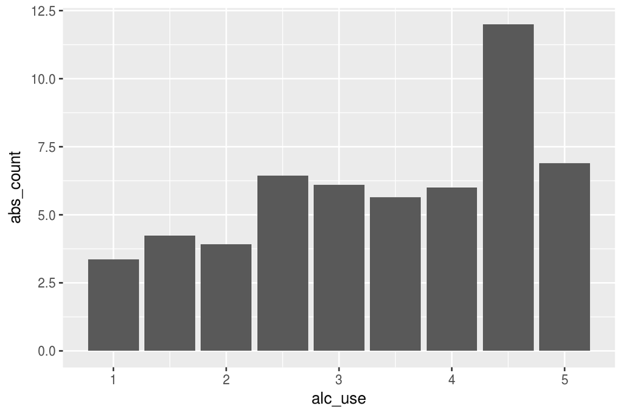

```r
bar_absences=ggplot(tab_sum,aes(x=alc_use,y=abs_count))+geom_bar(stat='identity'); bar_absences
```

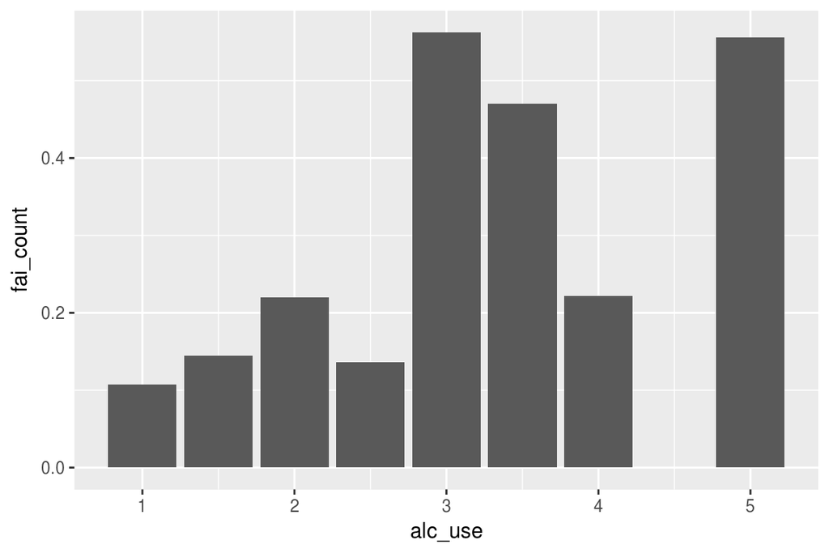

```r
bar_failures=ggplot(tab_sum,aes(x=alc_use,y=fai_count))+geom_bar(stat='identity'); bar_failures
```

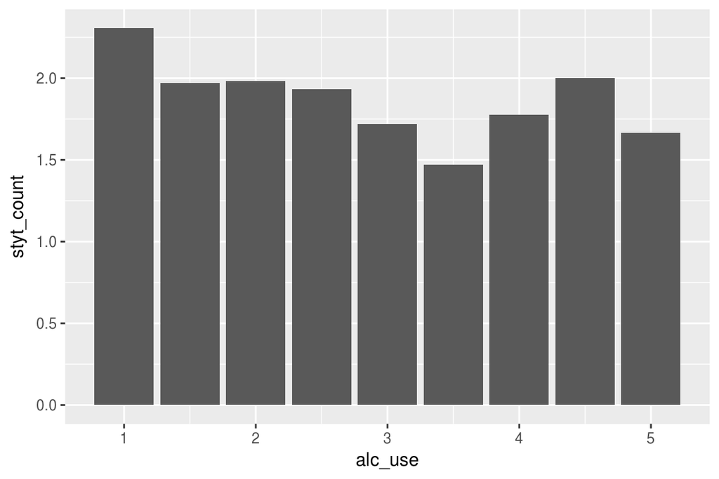

```r
bar_studytime=ggplot(tab_sum,aes(x=alc_use,y=styt_count))+geom_bar(stat='identity'); bar_studytime
```

`absences`~`alc_use`:  
There ia an increasing trend with absenses and alcohol use, which is in line with our hypothesis. When the alcohol use is 4.5, the absence is extremely high. The second high absence happens when the alcohol use is on the highest level.  
`failures`~`alc_use`:  
There is an positive correlation between failures and alcohol use. For light alcohol users, the failures are also in a low level, however, the failure reaches the highest mount when `alc_use`= 3. After that the failures fall down with incresing alcohol use, and we interpret this as lacking of enough samples. For extreme high alcohol users (`alc_use`=5), the failures are at the highest level, the same as `alc_use`=3.  
`studytime`~`alc_use`:  
The figure shows that there is no obvious relations between the study time and alcohol use. This is not in agreement with our hypothesis before. The lowest alcohol users have the most study time and the study time of the highest users are low compared with the other alcohol using levels. But the difference bwteen them are not quite obvious.

### Box plots by goups

Box plots are an excellent way of displaying and comparing distributions. The box visualizes the percentiles of the 25th, 50th and 75th of the data, while the whiskers show the typical range and the ourliers of a variable.

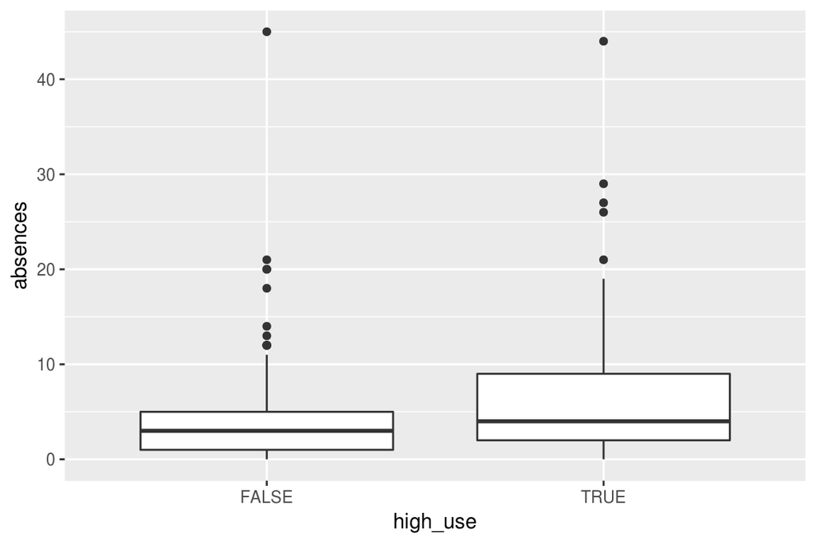

```r
box_absences=ggplot(alc,aes(x=high_use,y=absences))+geom_boxplot(); box_absences
```

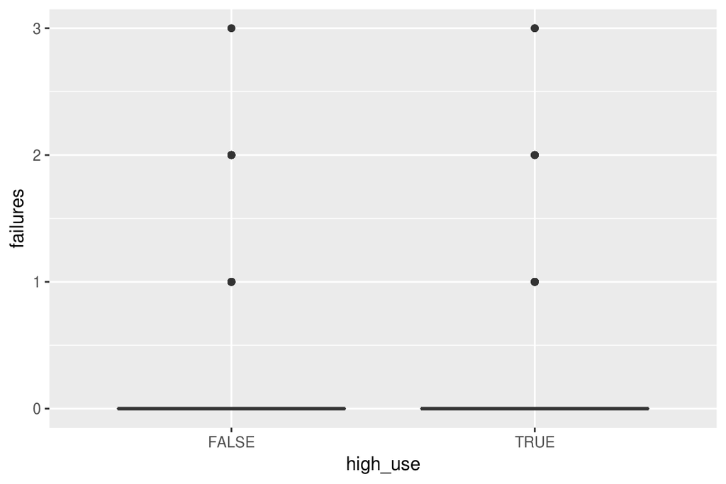

```r
box_failures=ggplot(alc,aes(x=high_use,y=failures))+geom_boxplot(); box_failures
```

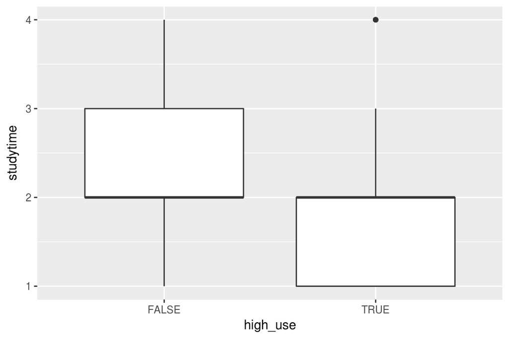

```r
box_studytime=ggplot(alc,aes(x=high_use,y=studytime))+geom_boxplot(); box_studytime
```

From the box plot of `absences` vs. `high_use`, it is obvious that the high alcohol users (`alc_use` > 2) are most likely to be absent from school. The box plot of `studytime` vs. `high_use` shows that high alcohol use also reduces the study time of the students. The conclusiona are in line with our hypothesis before.

## Step 4: Logistic regression

The logistic regression is used here to identify factors (failures,absences,sex and studytime) related to higher than average student alcohol consumption.

```r
m=glm(high_use~failures+absences+sex+studytime, data=alc,family='binomial')
summary(m)
```

```
##
## Call:
## glm(formula = high_use ~ failures + absences + sex + studytime,
##     family = "binomial", data = alc)
##
## Deviance Residuals:
##     Min       1Q   Median       3Q      Max
## -2.1213  -0.8226  -0.6017   1.0824   2.1185
##
## Coefficients:
##             Estimate Std. Error z value Pr(>|z|)
## (Intercept) -1.11174    0.43028  -2.584 0.009773 **
## failures     0.36048    0.19472   1.851 0.064126 .
## absences     0.08734    0.02296   3.803 0.000143 ***
## sexM         0.79470    0.25212   3.152 0.001621 **
## studytime   -0.34003    0.16259  -2.091 0.036499 *
## ---
## Signif. codes:  0 '***' 0.001 '**' 0.01 '*' 0.05 '.' 0.1 ' ' 1
##
## (Dispersion parameter for binomial family taken to be 1)
##
##     Null deviance: 465.68  on 381  degrees of freedom
## Residual deviance: 419.82  on 377  degrees of freedom
## AIC: 429.82
##
## Number of Fisher Scoring iterations: 4
```

```r
coef(m)
```

```
## (Intercept)    failures    absences        sexM   studytime
## -1.11173770  0.36048380  0.08734126  0.79469663 -0.34003347
```

According to the summary results, the estimated coefficients for failures, absences, sexM and studytime are 0.360, 0.087, 0.795 and -0.340 respectively. The results show that, for failures, absences and sexM, the correlations between them and alcohol use are positive while for studytime, the correlation is negative. This is in agreement with our previous hypothesis. According to the `P value` shown in the summary part, the biggest possibility happens between `absences` and `high_use`. The relation between `failures` and `high_use` may seem not quite convincing and this is in agreement with the box plot shown in the last part.

```r
OR=coef(m) %>% exp
CI=confint(m) %>% exp
cbind(OR,CI)
```

```
##                    OR     2.5 %    97.5 %
## (Intercept) 0.3289868 0.1402796 0.7609560
## failures    1.4340230 0.9804979 2.1153252
## absences    1.0912690 1.0455005 1.1442053
## sexM        2.2137693 1.3559547 3.6508476
## studytime   0.7117465 0.5129770 0.9721184
```

The ratio of expected “success” to “failures” are called the odds: p/(1-p). Odds are an alternative way of expressing probabilities. Higher odds corresponds to a higher probability of success when OR > 1. Odds higher than 1 means that X is positively associated with “success”. If OR < 1, lower odds corresponds to the higher probability of success. The computational target variable in the logistic regression model is the log of odds, so applying exponent function to the modelled values gives the odds.  
From the summary of the odds one can see that sexM gives the largest odds. This means that sexM has higher probability to high alcolhol use compared to failures and absences. The odds of studytime is the lower than 1. The result indicate that higher alcohol use corresponds to less study time.  
The confidence intervals of 2.5% and 97.5 % for the odd ratios are also listed in the data frame.

## Step 5: Binary predictions

predict() the probability of high_use

```r
probabilities <- predict(m, type = "response")
alc <- mutate(alc, probability = probabilities)
alc <- mutate(alc, prediction = probability>0.5)
select(alc, failures, absences, sex, studytime, high_use, probability, prediction) %>% tail(10)
```

```
##     failures absences sex studytime high_use probability prediction
## 373        1        0   M         1    FALSE   0.4263911      FALSE
## 374        1        7   M         1     TRUE   0.5780560       TRUE
## 375        0        1   F         3    FALSE   0.1146096      FALSE
## 376        0        6   F         1    FALSE   0.2833868      FALSE
## 377        1        2   F         3    FALSE   0.1684473      FALSE
## 378        0        2   F         2    FALSE   0.1656021      FALSE
## 379        2        2   F         2    FALSE   0.2898414      FALSE
## 380        0        3   F         2    FALSE   0.1780258      FALSE
## 381        0        4   M         1     TRUE   0.4236739      FALSE
## 382        0        2   M         1     TRUE   0.3816874      FALSE
```

```r
table(high_use = alc$high_use, prediction = alc$prediction)%>%addmargins
```

```
##         prediction
## high_use FALSE TRUE Sum
##    FALSE   256   12 268
##    TRUE     80   34 114
##    Sum     336   46 382
```

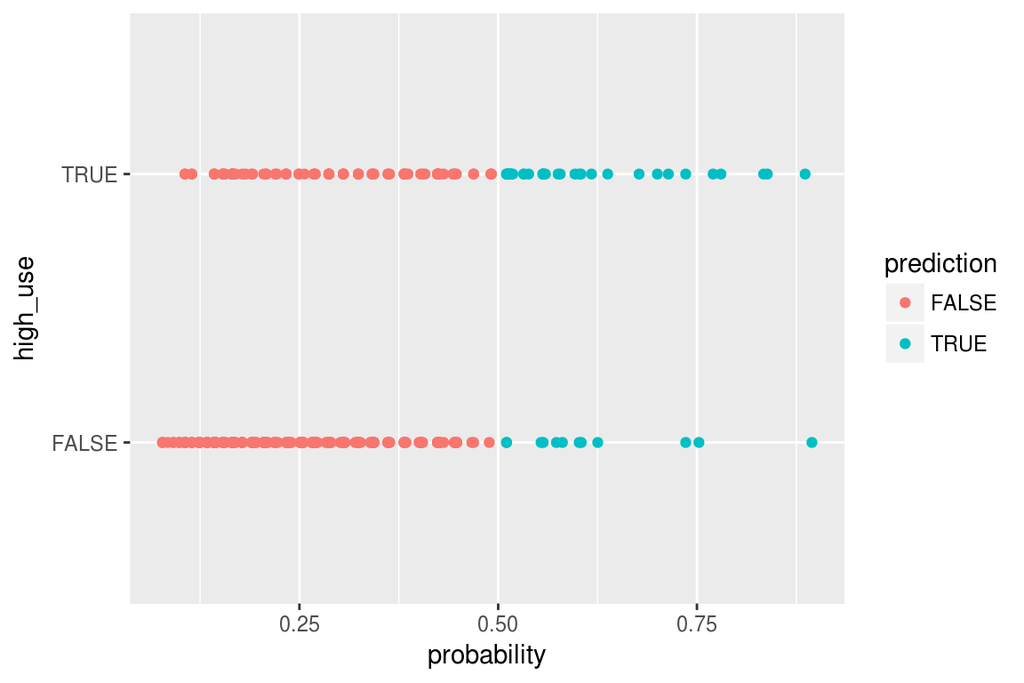

```r
g=ggplot(alc, aes(x = probability, y = high_use, col=prediction))
g=g+geom_point()
g
```

```r
table(high_use = alc$high_use, prediction = alc$prediction)%>% prop.table%>%addmargins
```

```
##         prediction
## high_use      FALSE       TRUE        Sum
##    FALSE 0.67015707 0.03141361 0.70157068
##    TRUE  0.20942408 0.08900524 0.29842932
##    Sum   0.87958115 0.12041885 1.00000000
```

According to the last 10 rows of data, we can see that most of the predictions are correct, except for the last two one. The last two samples are high alcohol users however, the prediction show that they are not, which is incorrect.  
The cross tabulation of predictions versus the actual values show that 256 out of 268 `FALSE`(non-high alcohol users) values were predicted correctly by the model, while only 34 of 114 `TRUE`(high alcohol users) were predicted correctly. The correct prediction rate of `FALSE` samples is 95.5% while the correct prediction rate of `TRUE` samples is only 29.8%.  
The results show that the model could give relatively good predictions for `FALSE` results while for the prediction of `TRUE` results is not sensitive.

## Step 6: Compute the average number of incorrect predictions

Accuracy: the average number of correctly classified observations. Penalty (loss) function: the mean of incorrectly classified observations. Less penalty function means better predictions.

```r
# define a loss function (mean prediction error)
loss_func <- function(class, prob) {
  n_wrong <- abs(class - prob) > 0.5
  mean(n_wrong)
}
# call loss_func to compute the average number of wrong predictions in the data
loss_func(class = alc$high_use, prob = alc$probability)
```

```
## [1] 0.2408377
```

So, the wrong predictions of the model is about 24.1%. Combined with the analysis from step 5, we know that most of the wrong predictions are `TRUE` results (12 wrongly prediction for `FALSE` scenarios and 80 wrongly prediction for `TRUE` scenarios).

## Step 7: Cross-validation

Cross-validation is a method of testing a predictive model on unseen data. In cross-validation, the value of a penalty (loss) function (mean prediction error) is computed on data not used for finding the model. The low value of cross-validation result means better model predictions.  
Perform 10-fold cross-validation

```r
library(boot)
cv <- cv.glm(data = alc, cost = loss_func, glmfit = m, K = 10)
cv$delta[1]
```

```
## [1] 0.2460733
```

# Chapter 4 Clustering and classification

Created on 26.11.2017 @author: Xiaodong Li This is the script for RStudio exercise 4 – Clustering and classification The work focuses on exploring data and performing clustering methods which try to find the clusters (or groups) from the data. Clustering means that some points (or observations) of the data are in some sense closer to each other than some other points. Based on a successful clustering, we may try to classify new observations to these clusters and hence validate the results of clustering. This week’s data is the Boston data from the MASS package.

## Step 0: Import packages

```r
library(MASS)
```

```r
library(corrplot)
library(tidyr)
library(dplyr)
library(ggplot2)
```

## Step 1: Load and explore the data

```r
data("Boston")
str(Boston)
```

```
## 'data.frame':    506 obs. of  14 variables:
##  $ crim   : num  0.00632 0.02731 0.02729 0.03237 0.06905 ...
##  $ zn     : num  18 0 0 0 0 0 12.5 12.5 12.5 12.5 ...
##  $ indus  : num  2.31 7.07 7.07 2.18 2.18 2.18 7.87 7.87 7.87 7.87 ...
##  $ chas   : int  0 0 0 0 0 0 0 0 0 0 ...
##  $ nox    : num  0.538 0.469 0.469 0.458 0.458 0.458 0.524 0.524 0.524 0.524 ...
##  $ rm     : num  6.58 6.42 7.18 7 7.15 ...
##  $ age    : num  65.2 78.9 61.1 45.8 54.2 58.7 66.6 96.1 100 85.9 ...
##  $ dis    : num  4.09 4.97 4.97 6.06 6.06 ...
##  $ rad    : int  1 2 2 3 3 3 5 5 5 5 ...
##  $ tax    : num  296 242 242 222 222 222 311 311 311 311 ...
##  $ ptratio: num  15.3 17.8 17.8 18.7 18.7 18.7 15.2 15.2 15.2 15.2 ...
##  $ black  : num  397 397 393 395 397 ...
##  $ lstat  : num  4.98 9.14 4.03 2.94 5.33 ...
##  $ medv   : num  24 21.6 34.7 33.4 36.2 28.7 22.9 27.1 16.5 18.9 ...
```

```r
dim(Boston)
```

```
## [1] 506  14
```

The `Boston` data describes the housing values in the suburs of Boston. Is contains 14 variables which describe the situations of the housing environment like `crim`: per capita crime rate by town; `lstat`: lower status of the population (percent). In each variable there are 506 observations giving the detailed data of the coresponding variable.

## Step 2: The correlations between variables

The function `cor()` can be used to create the correlation matrix. A more visual way to look at the correlations is to use `corrplot()` function (from the corrplot package).

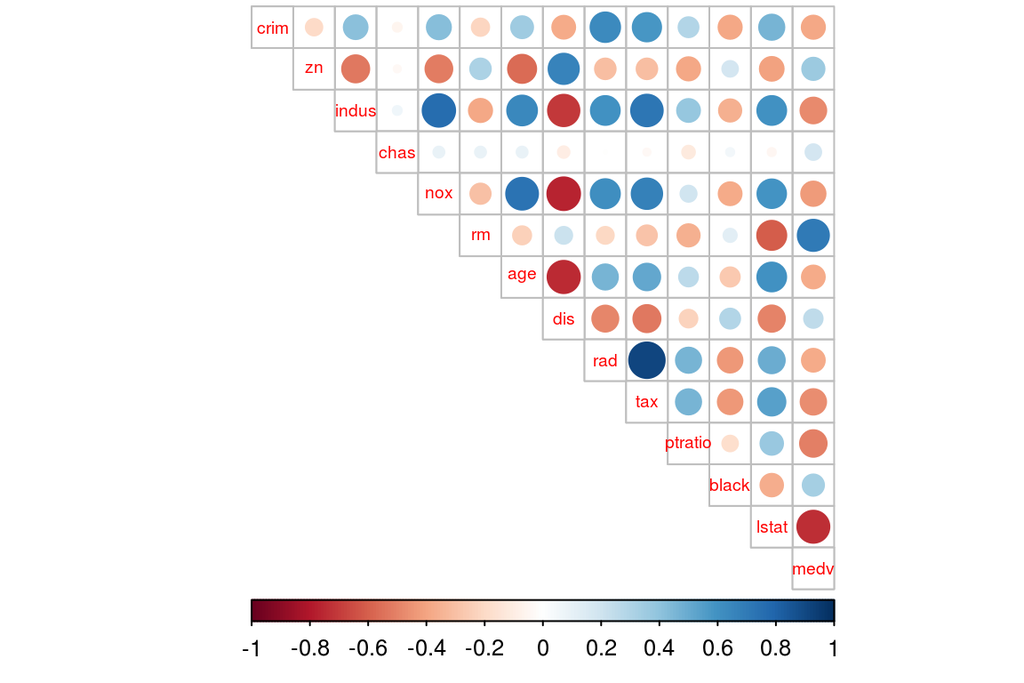

```r
cor_matrix<-cor(Boston) %>% round(2)
corrplot(cor_matrix, method="circle",type='upper',cl.pos='b',tl.pos='d',tl.cex=0.6)
```

The corrplot shows the correlations between variables of the Boston dataset. The darker color in the corrplot indicates more straight corelation. Blue color means a positive correlation while red color means a negative correlation. Then from the figure we can summarise that `rad` (index of accessibility to radial highways) and `tax` (full-value property-tax rate per $10000) have very strong positive correlation. And `dis` (weighted mean of distances to five Boston employment centres) very strong negative correlations with `nox` (nitrogen oxides concentration), `age` (proportion of owner-occupied units built prior to 1940) and `indux` (proportion of non-retail business acres per town). `medv` (meidan value of owner-occupied homes in $1000) and `lstat` (lower status of the population) have very strong negative correlation too.

## Step 3: Scale the whole dataset

In the scaling we subtract the column means from the corresponding columns and divide the difference with standard deviation.  
$scaled(x) = \frac{x - mean(x)}{ sd(x)}$

```r
boston_scaled <- scale(Boston)
summary(boston_scaled)
```

```
##       crim                 zn               indus
##  Min.   :-0.419367   Min.   :-0.48724   Min.   :-1.5563
##  1st Qu.:-0.410563   1st Qu.:-0.48724   1st Qu.:-0.8668
##  Median :-0.390280   Median :-0.48724   Median :-0.2109
##  Mean   : 0.000000   Mean   : 0.00000   Mean   : 0.0000
##  3rd Qu.: 0.007389   3rd Qu.: 0.04872   3rd Qu.: 1.0150
##  Max.   : 9.924110   Max.   : 3.80047   Max.   : 2.4202
##       chas              nox                rm               age
##  Min.   :-0.2723   Min.   :-1.4644   Min.   :-3.8764   Min.   :-2.3331
##  1st Qu.:-0.2723   1st Qu.:-0.9121   1st Qu.:-0.5681   1st Qu.:-0.8366
##  Median :-0.2723   Median :-0.1441   Median :-0.1084   Median : 0.3171
##  Mean   : 0.0000   Mean   : 0.0000   Mean   : 0.0000   Mean   : 0.0000
##  3rd Qu.:-0.2723   3rd Qu.: 0.5981   3rd Qu.: 0.4823   3rd Qu.: 0.9059
##  Max.   : 3.6648   Max.   : 2.7296   Max.   : 3.5515   Max.   : 1.1164
##       dis               rad               tax             ptratio
##  Min.   :-1.2658   Min.   :-0.9819   Min.   :-1.3127   Min.   :-2.7047
##  1st Qu.:-0.8049   1st Qu.:-0.6373   1st Qu.:-0.7668   1st Qu.:-0.4876
##  Median :-0.2790   Median :-0.5225   Median :-0.4642   Median : 0.2746
##  Mean   : 0.0000   Mean   : 0.0000   Mean   : 0.0000   Mean   : 0.0000
##  3rd Qu.: 0.6617   3rd Qu.: 1.6596   3rd Qu.: 1.5294   3rd Qu.: 0.8058
##  Max.   : 3.9566   Max.   : 1.6596   Max.   : 1.7964   Max.   : 1.6372
##      black             lstat              medv
##  Min.   :-3.9033   Min.   :-1.5296   Min.   :-1.9063
##  1st Qu.: 0.2049   1st Qu.:-0.7986   1st Qu.:-0.5989
##  Median : 0.3808   Median :-0.1811   Median :-0.1449
##  Mean   : 0.0000   Mean   : 0.0000   Mean   : 0.0000
##  3rd Qu.: 0.4332   3rd Qu.: 0.6024   3rd Qu.: 0.2683
##  Max.   : 0.4406   Max.   : 3.5453   Max.   : 2.9865
```

The variables changed according to the formula shown above. After the scaling, we can see that the data are all quite near 0 which is the mean value of the variable. Negative values mean that the data are less than the mean value while the positive figures mean that the data are bigger values than the mean value.  
We want to cut the variable by quantiles to get the high, low and middle rates of crime into their own categories.

```r
boston_scaled=as.data.frame(boston_scaled)
bins=quantile(boston_scaled$crim)
crime=cut(boston_scaled$crim, breaks = bins, include.lowest = TRUE, label = c('low','med_low','med_high','high'))
table(crime)
```

```
## crime
##      low  med_low med_high     high
##      127      126      126      127
```

```r
boston_scaled=dplyr::select(boston_scaled, -crim)
boston_scaled=data.frame(boston_scaled, crime)
n <- nrow(boston_scaled)
ind <- sample(n,  size = n * 0.8)
train <- boston_scaled[ind,]
test <- boston_scaled[-ind,]
correct_classes <- test$crime
test <- dplyr::select(test, -crime)
```

First, we use the quantiles as the break points and creat a categorical variable of the crime rate in the Boston dataset. Then the old crime rate variable is dropped from the old crime rate variable. And then the dataset is divided into train and test sets where 80% of the data belongs to the train set.